# 04.decision_tree_initail_model

Youngjin_Lee

2022 3 10

# 1 초기 모델(Initia Model)

## 1.1 유니버설 은행 사례 Figure 9.9

tidyverse: ggplot2, purrr, tibble 3.0.3,  
dplyr, tidyr, stringr, readr, forcats  
—  
tidymodels: broom, recipes, dials, rsample, infer,  
tune, modeldata, workflows, parsnip, yardstick  
—

## 1.2 데이터 불러오기

textbook p.5 ~ 12 참조

```r
bank_tb <- read_csv('../data/UniversalBank.csv',
                    col_names = TRUE,
                    locale=locale('ko', encoding='euc-kr'),
                    na=".") %>% # csv 데이터 읽어오기
  mutate_if(is.character, as.factor)
str(bank_tb)
```

```
## spec_tbl_df [5,000 x 14] (S3: spec_tbl_df/tbl_df/tbl/data.frame)
##  $ ID                : num [1:5000] 1 2 3 4 5 6 7 8 9 10 ...
##  $ Age               : num [1:5000] 25 45 39 35 35 37 53 50 35 34 ...
##  $ Experience        : num [1:5000] 1 19 15 9 8 13 27 24 10 9 ...
##  $ Income            : num [1:5000] 49 34 11 100 45 29 72 22 81 180 ...
##  $ ZIP Code          : num [1:5000] 91107 90089 94720 94112 91330 ...
##  $ Family            : num [1:5000] 4 3 1 1 4 4 2 1 3 1 ...
##  $ CCAvg             : num [1:5000] 1.6 1.5 1 2.7 1 0.4 1.5 0.3 0.6 8.9 ...
##  $ Education         : num [1:5000] 1 1 1 2 2 2 2 3 2 3 ...
##  $ Mortgage          : num [1:5000] 0 0 0 0 0 155 0 0 104 0 ...
##  $ Personal Loan     : num [1:5000] 0 0 0 0 0 0 0 0 0 1 ...
##  $ Securities Account: num [1:5000] 1 1 0 0 0 0 0 0 0 0 ...
##  $ CD Account        : num [1:5000] 0 0 0 0 0 0 0 0 0 0 ...
##  $ Online            : num [1:5000] 0 0 0 0 0 1 1 0 1 0 ...
##  $ CreditCard        : num [1:5000] 0 0 0 0 1 0 0 1 0 0 ...
##  - attr(*, "spec")=
##   .. cols(
##   ..   ID = col_double(),
##   ..   Age = col_double(),
##   ..   Experience = col_double(),
##   ..   Income = col_double(),
##   ..   `ZIP Code` = col_double(),
##   ..   Family = col_double(),
##   ..   CCAvg = col_double(),
##   ..   Education = col_double(),
##   ..   Mortgage = col_double(),
##   ..   `Personal Loan` = col_double(),
##   ..   `Securities Account` = col_double(),
##   ..   `CD Account` = col_double(),
##   ..   Online = col_double(),
##   ..   CreditCard = col_double()
##   .. )
##  - attr(*, "problems")=<externalptr>
```

```r
head(bank_tb)
```

```
## # A tibble: 6 x 14
##      ID   Age Experience Income `ZIP Code` Family CCAvg Education Mortgage
##   <dbl> <dbl>      <dbl>  <dbl>      <dbl>  <dbl> <dbl>     <dbl>    <dbl>
## 1     1    25          1     49      91107      4   1.6         1        0
## 2     2    45         19     34      90089      3   1.5         1        0
## 3     3    39         15     11      94720      1   1           1        0
## 4     4    35          9    100      94112      1   2.7         2        0
## 5     5    35          8     45      91330      4   1           2        0
## 6     6    37         13     29      92121      4   0.4         2      155
## # ... with 5 more variables: `Personal Loan` <dbl>, `Securities Account` <dbl>,
## #   `CD Account` <dbl>, Online <dbl>, CreditCard <dbl>
```

## 1.3 data 전처리

변수명 수정 (공란이 있을 경우에 변수명 수정)

```r
bank_tb <- bank_tb %>%
  rename(c('Personal_Loan'= 'Personal Loan',
           'CD_Account' = 'CD Account',
           'Securities_Account' = 'Securities Account'))
str(bank_tb)
```

```
## spec_tbl_df [5,000 x 14] (S3: spec_tbl_df/tbl_df/tbl/data.frame)
##  $ ID                : num [1:5000] 1 2 3 4 5 6 7 8 9 10 ...
##  $ Age               : num [1:5000] 25 45 39 35 35 37 53 50 35 34 ...
##  $ Experience        : num [1:5000] 1 19 15 9 8 13 27 24 10 9 ...
##  $ Income            : num [1:5000] 49 34 11 100 45 29 72 22 81 180 ...
##  $ ZIP Code          : num [1:5000] 91107 90089 94720 94112 91330 ...
##  $ Family            : num [1:5000] 4 3 1 1 4 4 2 1 3 1 ...
##  $ CCAvg             : num [1:5000] 1.6 1.5 1 2.7 1 0.4 1.5 0.3 0.6 8.9 ...
##  $ Education         : num [1:5000] 1 1 1 2 2 2 2 3 2 3 ...
##  $ Mortgage          : num [1:5000] 0 0 0 0 0 155 0 0 104 0 ...
##  $ Personal_Loan     : num [1:5000] 0 0 0 0 0 0 0 0 0 1 ...
##  $ Securities_Account: num [1:5000] 1 1 0 0 0 0 0 0 0 0 ...
##  $ CD_Account        : num [1:5000] 0 0 0 0 0 0 0 0 0 0 ...
##  $ Online            : num [1:5000] 0 0 0 0 0 1 1 0 1 0 ...
##  $ CreditCard        : num [1:5000] 0 0 0 0 1 0 0 1 0 0 ...
##  - attr(*, "spec")=
##   .. cols(
##   ..   ID = col_double(),
##   ..   Age = col_double(),
##   ..   Experience = col_double(),
##   ..   Income = col_double(),
##   ..   `ZIP Code` = col_double(),
##   ..   Family = col_double(),
##   ..   CCAvg = col_double(),
##   ..   Education = col_double(),
##   ..   Mortgage = col_double(),
##   ..   `Personal Loan` = col_double(),
##   ..   `Securities Account` = col_double(),
##   ..   `CD Account` = col_double(),
##   ..   Online = col_double(),
##   ..   CreditCard = col_double()
##   .. )
##  - attr(*, "problems")=<externalptr>
```

```r
head(bank_tb)
```

```
## # A tibble: 6 x 14
##      ID   Age Experience Income `ZIP Code` Family CCAvg Education Mortgage
##   <dbl> <dbl>      <dbl>  <dbl>      <dbl>  <dbl> <dbl>     <dbl>    <dbl>
## 1     1    25          1     49      91107      4   1.6         1        0
## 2     2    45         19     34      90089      3   1.5         1        0
## 3     3    39         15     11      94720      1   1           1        0
## 4     4    35          9    100      94112      1   2.7         2        0
## 5     5    35          8     45      91330      4   1           2        0
## 6     6    37         13     29      92121      4   0.4         2      155
## # ... with 5 more variables: Personal_Loan <dbl>, Securities_Account <dbl>,
## #   CD_Account <dbl>, Online <dbl>, CreditCard <dbl>
```

범주형 변수(factor)로 인식하게 변환 결과변수(class)에서 관심있는 변수를 1번으로 세팅

```r
bank_tb <- bank_tb %>%
  mutate(Personal_Loan = factor(Personal_Loan,
                                levels = c(1, 0),              #관심변수=Yes
                                labels = c("Yes", "No"))) %>%
  mutate(Securities_Account = factor(Securities_Account,
                                     levels = c(0,1),
                                     labels = c("No", "Yes"))) %>%
  mutate(CD_Account  = factor(CD_Account,
                              levels = c(0,1),
                              labels = c("No", "Yes"))) %>%
  mutate(Online = factor(Online,
                         levels = c(0,1),
                         labels = c("No", "Yes"))) %>%
  mutate(CreditCard = factor(CreditCard,
                             levels = c(0,1),
                             labels = c("No", "Yes"))) %>%
  mutate(Education  = factor(Education ,
                             levels = c(1:3),
                             labels = c("Undergrad",
                                        "Graduate",
                                        "Professional")))

str(bank_tb)
```

```
## spec_tbl_df [5,000 x 14] (S3: spec_tbl_df/tbl_df/tbl/data.frame)
##  $ ID                : num [1:5000] 1 2 3 4 5 6 7 8 9 10 ...
##  $ Age               : num [1:5000] 25 45 39 35 35 37 53 50 35 34 ...
##  $ Experience        : num [1:5000] 1 19 15 9 8 13 27 24 10 9 ...
##  $ Income            : num [1:5000] 49 34 11 100 45 29 72 22 81 180 ...
##  $ ZIP Code          : num [1:5000] 91107 90089 94720 94112 91330 ...
##  $ Family            : num [1:5000] 4 3 1 1 4 4 2 1 3 1 ...
##  $ CCAvg             : num [1:5000] 1.6 1.5 1 2.7 1 0.4 1.5 0.3 0.6 8.9 ...
##  $ Education         : Factor w/ 3 levels "Undergrad","Graduate",..: 1 1 1 2 2 2 2 3 2 3 ...
##  $ Mortgage          : num [1:5000] 0 0 0 0 0 155 0 0 104 0 ...
##  $ Personal_Loan     : Factor w/ 2 levels "Yes","No": 2 2 2 2 2 2 2 2 2 1 ...
##  $ Securities_Account: Factor w/ 2 levels "No","Yes": 2 2 1 1 1 1 1 1 1 1 ...
##  $ CD_Account        : Factor w/ 2 levels "No","Yes": 1 1 1 1 1 1 1 1 1 1 ...
##  $ Online            : Factor w/ 2 levels "No","Yes": 1 1 1 1 1 2 2 1 2 1 ...
##  $ CreditCard        : Factor w/ 2 levels "No","Yes": 1 1 1 1 2 1 1 2 1 1 ...
##  - attr(*, "spec")=
##   .. cols(
##   ..   ID = col_double(),
##   ..   Age = col_double(),
##   ..   Experience = col_double(),
##   ..   Income = col_double(),
##   ..   `ZIP Code` = col_double(),
##   ..   Family = col_double(),
##   ..   CCAvg = col_double(),
##   ..   Education = col_double(),
##   ..   Mortgage = col_double(),
##   ..   `Personal Loan` = col_double(),
##   ..   `Securities Account` = col_double(),
##   ..   `CD Account` = col_double(),
##   ..   Online = col_double(),
##   ..   CreditCard = col_double()
##   .. )
##  - attr(*, "problems")=<externalptr>
```

```r
head(bank_tb)
```

```
## # A tibble: 6 x 14
##      ID   Age Experience Income `ZIP Code` Family CCAvg Education Mortgage
##   <dbl> <dbl>      <dbl>  <dbl>      <dbl>  <dbl> <dbl> <fct>        <dbl>
## 1     1    25          1     49      91107      4   1.6 Undergrad        0
## 2     2    45         19     34      90089      3   1.5 Undergrad        0
## 3     3    39         15     11      94720      1   1   Undergrad        0
## 4     4    35          9    100      94112      1   2.7 Graduate         0
## 5     5    35          8     45      91330      4   1   Graduate         0
## 6     6    37         13     29      92121      4   0.4 Graduate       155
## # ... with 5 more variables: Personal_Loan <fct>, Securities_Account <fct>,
## #   CD_Account <fct>, Online <fct>, CreditCard <fct>
```

필요없는 변수제거: ID, 우편번호 제거 recipe에서 제거할 수도 있음

```r
bank_tb <- bank_tb %>%
  select(-c(ID, `ZIP Code`))

str(bank_tb)
```

```
## tibble [5,000 x 12] (S3: tbl_df/tbl/data.frame)
##  $ Age               : num [1:5000] 25 45 39 35 35 37 53 50 35 34 ...
##  $ Experience        : num [1:5000] 1 19 15 9 8 13 27 24 10 9 ...
##  $ Income            : num [1:5000] 49 34 11 100 45 29 72 22 81 180 ...
##  $ Family            : num [1:5000] 4 3 1 1 4 4 2 1 3 1 ...
##  $ CCAvg             : num [1:5000] 1.6 1.5 1 2.7 1 0.4 1.5 0.3 0.6 8.9 ...
##  $ Education         : Factor w/ 3 levels "Undergrad","Graduate",..: 1 1 1 2 2 2 2 3 2 3 ...
##  $ Mortgage          : num [1:5000] 0 0 0 0 0 155 0 0 104 0 ...
##  $ Personal_Loan     : Factor w/ 2 levels "Yes","No": 2 2 2 2 2 2 2 2 2 1 ...
##  $ Securities_Account: Factor w/ 2 levels "No","Yes": 2 2 1 1 1 1 1 1 1 1 ...
##  $ CD_Account        : Factor w/ 2 levels "No","Yes": 1 1 1 1 1 1 1 1 1 1 ...
##  $ Online            : Factor w/ 2 levels "No","Yes": 1 1 1 1 1 2 2 1 2 1 ...
##  $ CreditCard        : Factor w/ 2 levels "No","Yes": 1 1 1 1 2 1 1 2 1 1 ...
```

```r
head(bank_tb)
```

```
## # A tibble: 6 x 12
##     Age Experience Income Family CCAvg Education Mortgage Personal_Loan
##   <dbl>      <dbl>  <dbl>  <dbl> <dbl> <fct>        <dbl> <fct>
## 1    25          1     49      4   1.6 Undergrad        0 No
## 2    45         19     34      3   1.5 Undergrad        0 No
## 3    39         15     11      1   1   Undergrad        0 No
## 4    35          9    100      1   2.7 Graduate         0 No
## 5    35          8     45      4   1   Graduate         0 No
## 6    37         13     29      4   0.4 Graduate       155 No
## # ... with 4 more variables: Securities_Account <fct>, CD_Account <fct>,
## #   Online <fct>, CreditCard <fct>
```

## 1.4 데이터 탐색(EDA)

데이터 탐색: 범주형, 연속형 구분 skimr::skim() - package명을 앞에 써서 구분 패키지를 여러개 사용할 경우에 이름이 같은 경우도 있어서 구분이 필요할 경우에 [패키지명::]을 사용

```r
bank_tb %>%
  skimr::skim()
```

Data summary

| Name | Piped data |
| --- | --- |
| Number of rows | 5000 |
| Number of columns | 12 |
| _______________________ |  |
| Column type frequency: |  |
| factor | 6 |
| numeric | 6 |
| ________________________ |  |
| Group variables | None |

**Variable type: factor**

| skim_variable | n_missing | complete_rate | ordered | n_unique | top_counts |
| --- | --- | --- | --- | --- | --- |
| Education | 0 | 1 | FALSE | 3 | Und: 2096, Pro: 1501, Gra: 1403 |
| Personal_Loan | 0 | 1 | FALSE | 2 | No: 4520, Yes: 480 |
| Securities_Account | 0 | 1 | FALSE | 2 | No: 4478, Yes: 522 |
| CD_Account | 0 | 1 | FALSE | 2 | No: 4698, Yes: 302 |
| Online | 0 | 1 | FALSE | 2 | Yes: 2984, No: 2016 |
| CreditCard | 0 | 1 | FALSE | 2 | No: 3530, Yes: 1470 |

**Variable type: numeric**

| skim_variable | n_missing | complete_rate | mean | sd | p0 | p25 | p50 | p75 | p100 | hist |
| --- | --- | --- | --- | --- | --- | --- | --- | --- | --- | --- |
| Age | 0 | 1 | 45.34 | 11.46 | 23 | 35.0 | 45.0 | 55.0 | 67 | ▅▇▇▇▆ |
| Experience | 0 | 1 | 20.10 | 11.47 | -3 | 10.0 | 20.0 | 30.0 | 43 | ▅▇▇▇▅ |
| Income | 0 | 1 | 73.77 | 46.03 | 8 | 39.0 | 64.0 | 98.0 | 224 | ▇▇▃▂▁ |
| Family | 0 | 1 | 2.40 | 1.15 | 1 | 1.0 | 2.0 | 3.0 | 4 | ▇▇▁▆▆ |
| CCAvg | 0 | 1 | 1.94 | 1.75 | 0 | 0.7 | 1.5 | 2.5 | 10 | ▇▃▁▁▁ |
| Mortgage | 0 | 1 | 56.50 | 101.71 | 0 | 0.0 | 0.0 | 101.0 | 635 | ▇▂▁▁▁ |

```r
bank_tb %>%
  group_by(Personal_Loan) %>%
  skimr::skim()
```

Data summary

| Name | Piped data |
| --- | --- |
| Number of rows | 5000 |
| Number of columns | 12 |
| _______________________ |  |
| Column type frequency: |  |
| factor | 5 |
| numeric | 6 |
| ________________________ |  |
| Group variables | Personal_Loan |

**Variable type: factor**

| skim_variable | Personal_Loan | n_missing | complete_rate | ordered | n_unique | top_counts |
| --- | --- | --- | --- | --- | --- | --- |
| Education | Yes | 0 | 1 | FALSE | 3 | Pro: 205, Gra: 182, Und: 93 |
| Education | No | 0 | 1 | FALSE | 3 | Und: 2003, Pro: 1296, Gra: 1221 |
| Securities_Account | Yes | 0 | 1 | FALSE | 2 | No: 420, Yes: 60 |
| Securities_Account | No | 0 | 1 | FALSE | 2 | No: 4058, Yes: 462 |
| CD_Account | Yes | 0 | 1 | FALSE | 2 | No: 340, Yes: 140 |
| CD_Account | No | 0 | 1 | FALSE | 2 | No: 4358, Yes: 162 |
| Online | Yes | 0 | 1 | FALSE | 2 | Yes: 291, No: 189 |
| Online | No | 0 | 1 | FALSE | 2 | Yes: 2693, No: 1827 |
| CreditCard | Yes | 0 | 1 | FALSE | 2 | No: 337, Yes: 143 |
| CreditCard | No | 0 | 1 | FALSE | 2 | No: 3193, Yes: 1327 |

**Variable type: numeric**

| skim_variable | Personal_Loan | n_missing | complete_rate | mean | sd | p0 | p25 | p50 | p75 | p100 | hist |
| --- | --- | --- | --- | --- | --- | --- | --- | --- | --- | --- | --- |
| Age | Yes | 0 | 1 | 45.07 | 11.59 | 26 | 35.0 | 45.0 | 55.00 | 65.0 | ▇▇▇▇▇ |
| Age | No | 0 | 1 | 45.37 | 11.45 | 23 | 35.0 | 45.0 | 55.00 | 67.0 | ▅▇▇▇▅ |
| Experience | Yes | 0 | 1 | 19.84 | 11.58 | 0 | 9.0 | 20.0 | 30.00 | 41.0 | ▇▇▇▇▆ |
| Experience | No | 0 | 1 | 20.13 | 11.46 | -3 | 10.0 | 20.0 | 30.00 | 43.0 | ▅▇▇▇▅ |
| Income | Yes | 0 | 1 | 144.75 | 31.58 | 60 | 122.0 | 142.5 | 172.00 | 203.0 | ▁▅▇▆▆ |
| Income | No | 0 | 1 | 66.24 | 40.58 | 8 | 35.0 | 59.0 | 84.00 | 224.0 | ▇▇▂▁▁ |
| Family | Yes | 0 | 1 | 2.61 | 1.12 | 1 | 2.0 | 3.0 | 4.00 | 4.0 | ▆▆▁▇▇ |
| Family | No | 0 | 1 | 2.37 | 1.15 | 1 | 1.0 | 2.0 | 3.00 | 4.0 | ▇▇▁▅▆ |
| CCAvg | Yes | 0 | 1 | 3.91 | 2.10 | 0 | 2.6 | 3.8 | 5.35 | 10.0 | ▅▇▇▃▁ |
| CCAvg | No | 0 | 1 | 1.73 | 1.57 | 0 | 0.6 | 1.4 | 2.30 | 8.8 | ▇▅▁▁▁ |
| Mortgage | Yes | 0 | 1 | 100.85 | 160.85 | 0 | 0.0 | 0.0 | 192.50 | 617.0 | ▇▁▁▁▁ |
| Mortgage | No | 0 | 1 | 51.79 | 92.04 | 0 | 0.0 | 0.0 | 98.00 | 635.0 | ▇▂▁▁▁ |

base accuracy yes 기준으로 0.096(yes인확률)

```r
bank_tb %>%
  count(Personal_Loan) %>%
  mutate(prop = n/sum(n))
```

```
## # A tibble: 2 x 3
##   Personal_Loan     n  prop
##   <fct>         <int> <dbl>
## 1 Yes             480 0.096
## 2 No             4520 0.904
```

## 1.5 훈련용, 테스트용 데이터 분할: partition

데이터 partition

```r
set.seed(123) # 시드 고정 (결과값을 유지)

bank_split <-
  initial_split(bank_tb, prop=0.7, # 비율 기본값 7;3(prop=0.7), train_data, test_data
                strata = Personal_Loan) # 결과변수 비율반영, strata(층화표본) 기준

bank_split
```

```
## <Analysis/Assess/Total>
## <3500/1500/5000>
```

training, test용 분리

```r
train_data <- training(bank_split)
test_data  <- testing(bank_split)
str(train_data)
```

```
## tibble [3,500 x 12] (S3: tbl_df/tbl/data.frame)
##  $ Age               : num [1:3500] 25 45 35 53 34 65 29 48 59 60 ...
##  $ Experience        : num [1:3500] 1 19 8 27 9 39 5 23 32 30 ...
##  $ Income            : num [1:3500] 49 34 45 72 180 105 45 114 40 22 ...
##  $ Family            : num [1:3500] 4 3 4 2 1 4 3 2 4 1 ...
##  $ CCAvg             : num [1:3500] 1.6 1.5 1 1.5 8.9 2.4 0.1 3.8 2.5 1.5 ...
##  $ Education         : Factor w/ 3 levels "Undergrad","Graduate",..: 1 1 2 2 3 3 2 3 2 3 ...
##  $ Mortgage          : num [1:3500] 0 0 0 0 0 0 0 0 0 0 ...
##  $ Personal_Loan     : Factor w/ 2 levels "Yes","No": 2 2 2 2 1 2 2 2 2 2 ...
##  $ Securities_Account: Factor w/ 2 levels "No","Yes": 2 2 1 1 1 1 1 2 1 1 ...
##  $ CD_Account        : Factor w/ 2 levels "No","Yes": 1 1 1 1 1 1 1 1 1 1 ...
##  $ Online            : Factor w/ 2 levels "No","Yes": 1 1 1 2 1 1 2 1 2 2 ...
##  $ CreditCard        : Factor w/ 2 levels "No","Yes": 1 1 2 1 1 1 1 1 1 2 ...
```

```r
str(test_data)
```

```
## tibble [1,500 x 12] (S3: tbl_df/tbl/data.frame)
##  $ Age               : num [1:1500] 39 35 37 50 35 67 29 44 59 53 ...
##  $ Experience        : num [1:1500] 15 9 13 24 10 41 5 18 35 28 ...
##  $ Income            : num [1:1500] 11 100 29 22 81 112 62 43 35 41 ...
##  $ Family            : num [1:1500] 1 1 4 1 3 1 1 2 1 2 ...
##  $ CCAvg             : num [1:1500] 1 2.7 0.4 0.3 0.6 2 1.2 0.7 1.2 0.6 ...
##  $ Education         : Factor w/ 3 levels "Undergrad","Graduate",..: 1 2 2 3 2 1 1 1 3 3 ...
##  $ Mortgage          : num [1:1500] 0 0 155 0 104 0 260 163 122 193 ...
##  $ Personal_Loan     : Factor w/ 2 levels "Yes","No": 2 2 2 2 2 2 2 2 2 2 ...
##  $ Securities_Account: Factor w/ 2 levels "No","Yes": 1 1 1 1 1 2 1 2 1 1 ...
##  $ CD_Account        : Factor w/ 2 levels "No","Yes": 1 1 1 1 1 1 1 1 1 1 ...
##  $ Online            : Factor w/ 2 levels "No","Yes": 1 1 2 1 2 1 2 1 2 1 ...
##  $ CreditCard        : Factor w/ 2 levels "No","Yes": 1 1 1 2 1 1 1 1 1 1 ...
```

## 1.6 Model 만들기

textbook p.31 ~ 36 설명 참조 ### Model 만들기 모델 인자(argument) 확인

```r
args(decision_tree)
```

```
## function (mode = "unknown", engine = "rpart", cost_complexity = NULL,
##     tree_depth = NULL, min_n = NULL)
## NULL
```

```r
tree_model <-
  decision_tree() %>% # function cost_complexity = NULL, tree_depth = NULL, min_n = NULL
  set_engine("rpart") %>%
  set_mode("classification")
```

### 1.6.1 recipe 만들기(데이터 튜닝)

step_dummy(all_nominal(), -all_outcomes()) : one-hot-ecoding 적용, 기본 step_log(Gr_Liv_Area, base = 10) : 로그함수로 변환 step_other(Neighborhood, threshold = 0.01) : 값이 적은 항목을 기타로 변환 step_upsample(Personal_Loan) # 데이터 균형화 step_zv(all_predictors()) : 단일 고유 값 (예 : 모두 0) 변수 제거. 특히, penalty 사용하는 모델에서 중요(logistic, SVM 등) step_normalize(all_numeric()) : 데이터 정규화

```r
tree_recipe <-
  recipe(Personal_Loan ~ ., data = train_data) %>%
  step_dummy(all_nominal(), -all_outcomes())

summary(tree_recipe)
```

```
## # A tibble: 12 x 4
##    variable           type    role      source
##    <chr>              <chr>   <chr>     <chr>
##  1 Age                numeric predictor original
##  2 Experience         numeric predictor original
##  3 Income             numeric predictor original
##  4 Family             numeric predictor original
##  5 CCAvg              numeric predictor original
##  6 Education          nominal predictor original
##  7 Mortgage           numeric predictor original
##  8 Securities_Account nominal predictor original
##  9 CD_Account         nominal predictor original
## 10 Online             nominal predictor original
## 11 CreditCard         nominal predictor original
## 12 Personal_Loan      nominal outcome   original
```

## 1.7 workflow 만들기

textbook p.39 설명참조

```r
tree_workflow <-
  workflow() %>%
  add_model(tree_model) %>%
  add_recipe(tree_recipe)

tree_workflow
```

```
## == Workflow ====================================================================
## Preprocessor: Recipe
## Model: decision_tree()
##
## -- Preprocessor ----------------------------------------------------------------
## 1 Recipe Step
##
## * step_dummy()
##
## -- Model -----------------------------------------------------------------------
## Decision Tree Model Specification (classification)
##
## Computational engine: rpart
```

## 1.8 Model 훈련

훈련데이터로 모델 훈련하기

```r
tree_train_fit <-
  tree_workflow %>%
  fit(data = train_data)
```

모델 훈련 결과 확인

```r
tree_train_fit %>%
  extract_fit_parsnip() # `pull_workflow_fit()` was deprecated in workflows 0.2.3.
```

```
## parsnip model object
##
## Fit time:  50ms
## n= 3500
##
## node), split, n, loss, yval, (yprob)
##       * denotes terminal node
##
##  1) root 3500 323 No (0.09228571 0.90771429)
##    2) Income>=100.5 822 296 No (0.36009732 0.63990268)
##      4) Family>=2.5 214  47 Yes (0.78037383 0.21962617)
##        8) Income>=114.5 147   2 Yes (0.98639456 0.01360544) *
##        9) Income< 114.5 67  22 No (0.32835821 0.67164179)
##         18) CCAvg>=2.75 20   6 Yes (0.70000000 0.30000000) *
##         19) CCAvg< 2.75 47   8 No (0.17021277 0.82978723) *
##      5) Family< 2.5 608 129 No (0.21217105 0.78782895)
##       10) Education_Professional>=0.5 94  19 Yes (0.79787234 0.20212766)
##         20) Income>=114.5 67   1 Yes (0.98507463 0.01492537) *
##         21) Income< 114.5 27   9 No (0.33333333 0.66666667) *
##       11) Education_Professional< 0.5 514  54 No (0.10505837 0.89494163)
##         22) Education_Graduate>=0.5 63  11 Yes (0.82539683 0.17460317)
##           44) Income>=116.5 46   0 Yes (1.00000000 0.00000000) *
##           45) Income< 116.5 17   6 No (0.35294118 0.64705882) *
##         23) Education_Graduate< 0.5 451   2 No (0.00443459 0.99556541) *
##    3) Income< 100.5 2678  27 No (0.01008215 0.98991785)
##      6) CCAvg>=2.95 160  27 No (0.16875000 0.83125000)
##       12) CD_Account_Yes>=0.5 9   1 Yes (0.88888889 0.11111111) *
##       13) CD_Account_Yes< 0.5 151  19 No (0.12582781 0.87417219) *
##      7) CCAvg< 2.95 2518   0 No (0.00000000 1.00000000) *
```

## 1.9 훈련모델 검정

textbook p.44 ~ 50 설명 참조 ### 예측결과표 생성

```r
tree_train_pred <-
  predict(tree_train_fit,
          train_data,
          type = "prob") %>%
  bind_cols(predict(tree_train_fit,
                    train_data)) %>%
  bind_cols(train_data %>%
              select(Personal_Loan)) %>%
  print()
```

```
## # A tibble: 3,500 x 4
##    .pred_Yes .pred_No .pred_class Personal_Loan
##        <dbl>    <dbl> <fct>       <fct>
##  1     0       1      No          No
##  2     0       1      No          No
##  3     0       1      No          No
##  4     0       1      No          No
##  5     0.985   0.0149 Yes         Yes
##  6     0.170   0.830  No          No
##  7     0       1      No          No
##  8     0.333   0.667  No          No
##  9     0       1      No          No
## 10     0       1      No          No
## # ... with 3,490 more rows
```

### 1.9.1 정오분류표(confusion matrix) 만들기

```r
tree_train_conf <-
  tree_train_pred  %>%
  conf_mat(truth = Personal_Loan,
           estimate = .pred_class)

tree_train_conf
```

```
##           Truth
## Prediction  Yes   No
##        Yes  279   10
##        No    44 3167
```

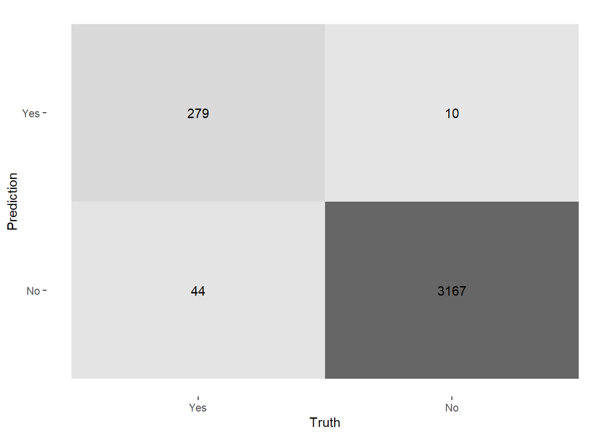

```r
autoplot(tree_train_conf, type = "heatmap") # mosaic
```

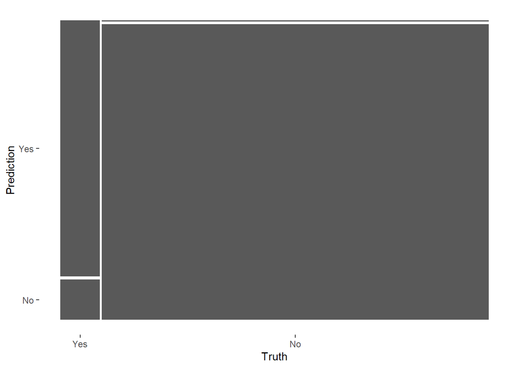

```r
autoplot(tree_train_conf, type = "mosaic")
```

```r
summary(tree_train_conf)
```

```
## # A tibble: 13 x 3
##    .metric              .estimator .estimate
##    <chr>                <chr>          <dbl>
##  1 accuracy             binary        0.985
##  2 kap                  binary        0.903
##  3 sens                 binary        0.864
##  4 spec                 binary        0.997
##  5 ppv                  binary        0.965
##  6 npv                  binary        0.986
##  7 mcc                  binary        0.905
##  8 j_index              binary        0.861
##  9 bal_accuracy         binary        0.930
## 10 detection_prevalence binary        0.0826
## 11 precision            binary        0.965
## 12 recall               binary        0.864
## 13 f_meas               binary        0.912
```

f1: 재현율(Recall)(↑)과 정밀도(Precision)(↑) 재현율(Recall): 실제 Class 중에 잘 맞춘 것(=TPR=민감도) 정밀도(Precision): 예측 Class 중에 잘 맞춘 것 정확도 (Accuracy) : 클래스 0과 1 모두를 정확하게 분류 ### ACU(area under the curve): ROC 정확도

```r
tree_train_pred %>%
  roc_auc(truth = Personal_Loan,
          .pred_Yes)
```

```
## # A tibble: 1 x 3
##   .metric .estimator .estimate
##   <chr>   <chr>          <dbl>
## 1 roc_auc binary         0.995
```

### 1.9.2 ROC 커브

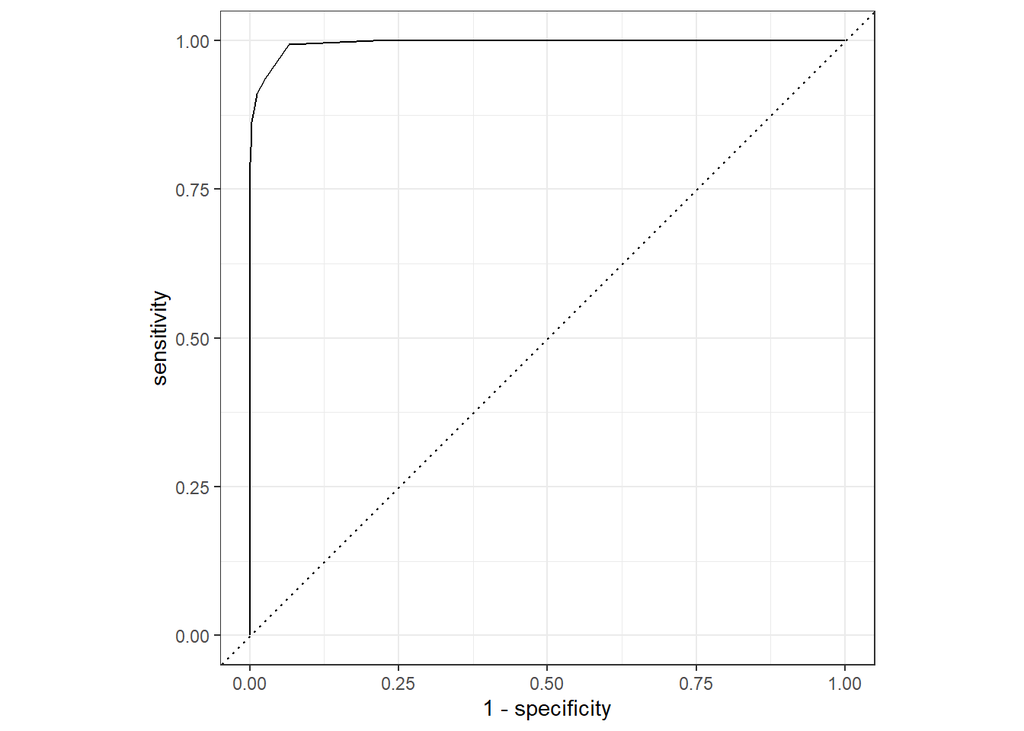

```r
train_auc <-
  tree_train_pred %>%
  roc_curve(truth = Personal_Loan,
            estimate = .pred_Yes) %>%
  mutate(model = "train_auc")

autoplot(train_auc)
```

### gain 커브

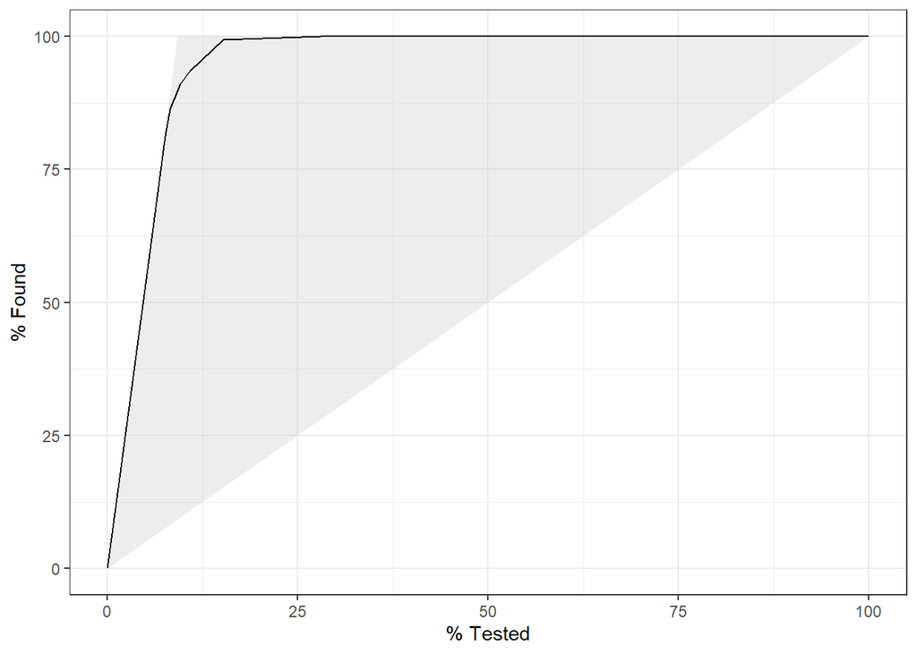

```r
tree_train_pred %>%
  gain_curve(truth = Personal_Loan,
             estimate = .pred_Yes) %>%
  autoplot()
```

### lift 커브

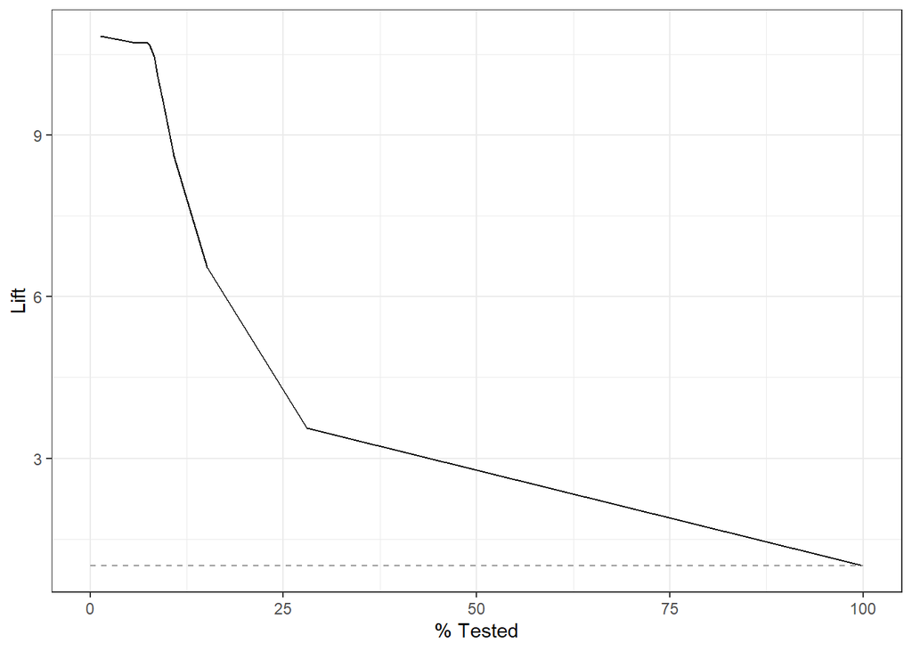

```r
tree_train_pred %>%
  lift_curve(truth = Personal_Loan,
             estimate = .pred_Yes) %>%
  autoplot()
```

### 중요변수 확인

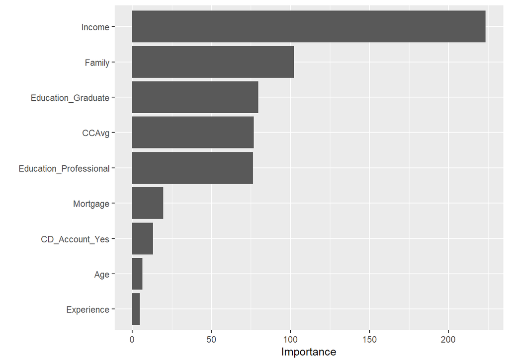

```r
tree_train_fit %>%
  extract_fit_parsnip() %>%  # pull_workflow_fit()` was deprecated in workflows 0.2.3.
  vip()
```

## 테스트 데이터 검정 구축된 모델에 test data로 검정 last_fit 사용 data: bank_split 사용(테스트는 전체데이터 = train + test)

```r
tree_test_fit <-
  tree_workflow %>%
  last_fit(bank_split)

tree_test_fit
```

```
## # Resampling results
## # Manual resampling
## # A tibble: 1 x 6
##   splits              id               .metrics .notes   .predictions .workflow
##   <list>              <chr>            <list>   <list>   <list>       <list>
## 1 <split [3500/1500]> train/test split <tibble> <tibble> <tibble>     <workflow>
```

### 1.9.3 예측결과 자동생성: collect_predictions()

```r
tree_test_pred <-
  tree_test_fit %>%
  collect_predictions()

tree_test_pred
```

```
## # A tibble: 1,500 x 7
##    id               .pred_Yes .pred_No  .row .pred_class Personal_Loan .config
##    <chr>                <dbl>    <dbl> <int> <fct>       <fct>         <chr>
##  1 train/test split   0          1         3 No          No            Preproce~
##  2 train/test split   0          1         4 No          No            Preproce~
##  3 train/test split   0          1         6 No          No            Preproce~
##  4 train/test split   0          1         8 No          No            Preproce~
##  5 train/test split   0          1         9 No          No            Preproce~
##  6 train/test split   0.00443    0.996    15 No          No            Preproce~
##  7 train/test split   0          1        23 No          No            Preproce~
##  8 train/test split   0          1        24 No          No            Preproce~
##  9 train/test split   0          1        31 No          No            Preproce~
## 10 train/test split   0          1        33 No          No            Preproce~
## # ... with 1,490 more rows
```

### 1.9.4 정오분류표(confusion matrix) 만들기

```r
tree_test_conf <-
  tree_test_pred  %>%
  conf_mat(truth = Personal_Loan,
           estimate = .pred_class)

tree_test_conf
```

```
##           Truth
## Prediction  Yes   No
##        Yes  142    7
##        No    15 1336
```

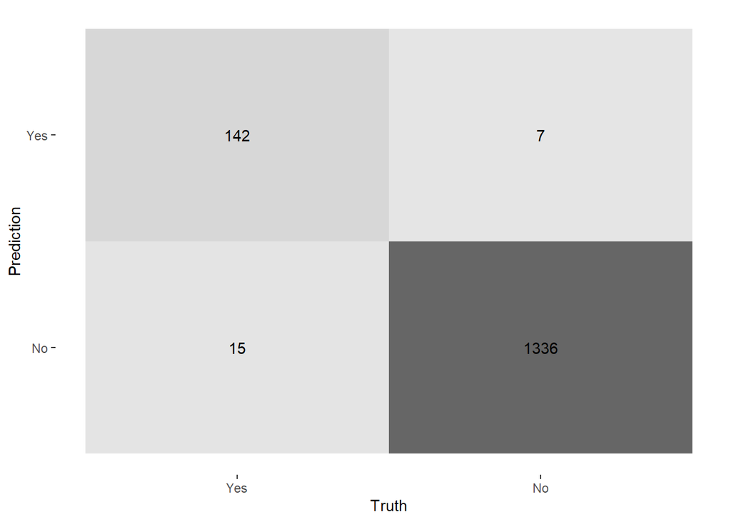

```r
autoplot(tree_test_conf, type = "heatmap") # mosaic
```

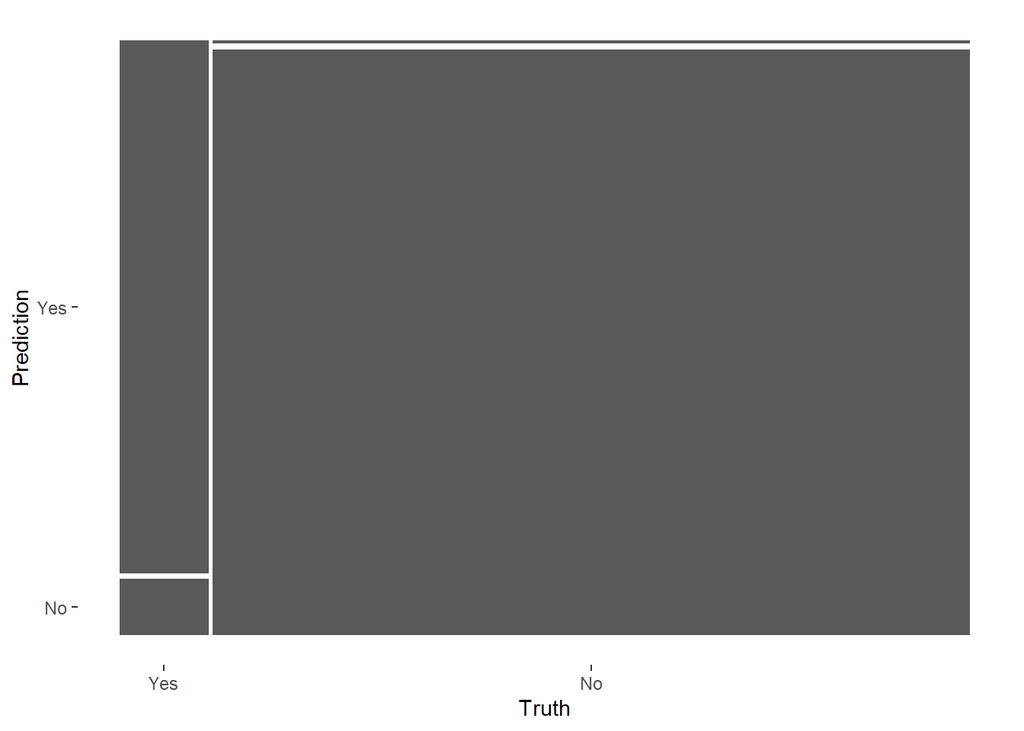

```r
autoplot(tree_test_conf, type = "mosaic")
```

```r
summary(tree_test_conf)
```

```
## # A tibble: 13 x 3
##    .metric              .estimator .estimate
##    <chr>                <chr>          <dbl>
##  1 accuracy             binary        0.985
##  2 kap                  binary        0.920
##  3 sens                 binary        0.904
##  4 spec                 binary        0.995
##  5 ppv                  binary        0.953
##  6 npv                  binary        0.989
##  7 mcc                  binary        0.920
##  8 j_index              binary        0.899
##  9 bal_accuracy         binary        0.950
## 10 detection_prevalence binary        0.0993
## 11 precision            binary        0.953
## 12 recall               binary        0.904
## 13 f_meas               binary        0.928
```

f1: 재현율(Recall)(↑)과 정밀도(Precision)(↑) 재현율(Recall): 실제 Class 중에 잘 맞춘 것(=TPR=민감도) 정밀도(Precision): 예측 Class 중에 잘 맞춘 것 정확도 (Accuracy) : 클래스 0과 1 모두를 정확하게 분류

### 1.9.5 ACU(area under the curve): ROC 정확도

```r
tree_test_pred %>%
  roc_auc(truth = Personal_Loan,
          .pred_Yes)
```

```
## # A tibble: 1 x 3
##   .metric .estimator .estimate
##   <chr>   <chr>          <dbl>
## 1 roc_auc binary         0.995
```

### 1.9.6 ROC 커브

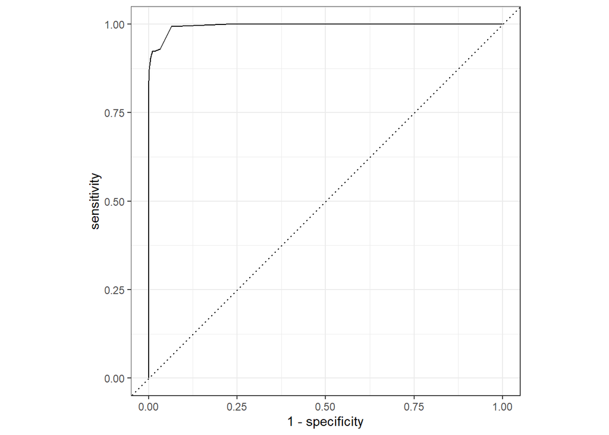

```r
test_auc <-
  tree_test_pred %>%
  roc_curve(truth = Personal_Loan,
            estimate = .pred_Yes) %>%
  mutate(model = "test_auc")

autoplot(test_auc)
```

### gain 커브

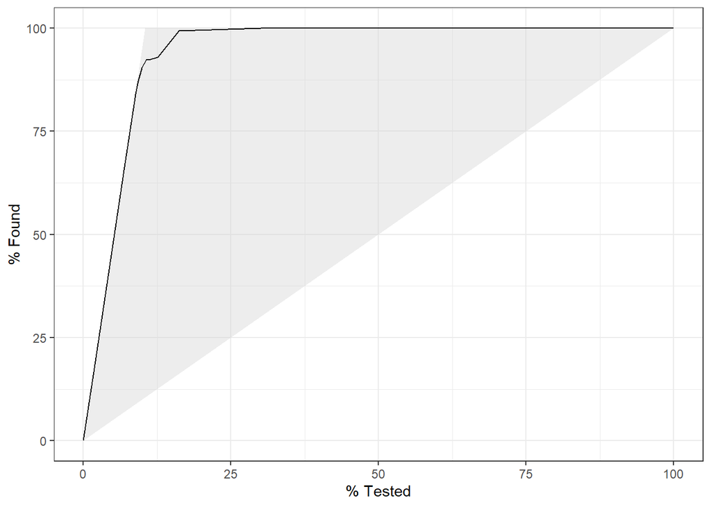

```r
tree_test_pred %>%
  gain_curve(truth = Personal_Loan,
             estimate = .pred_Yes) %>%
  autoplot()
```

### lift 커브

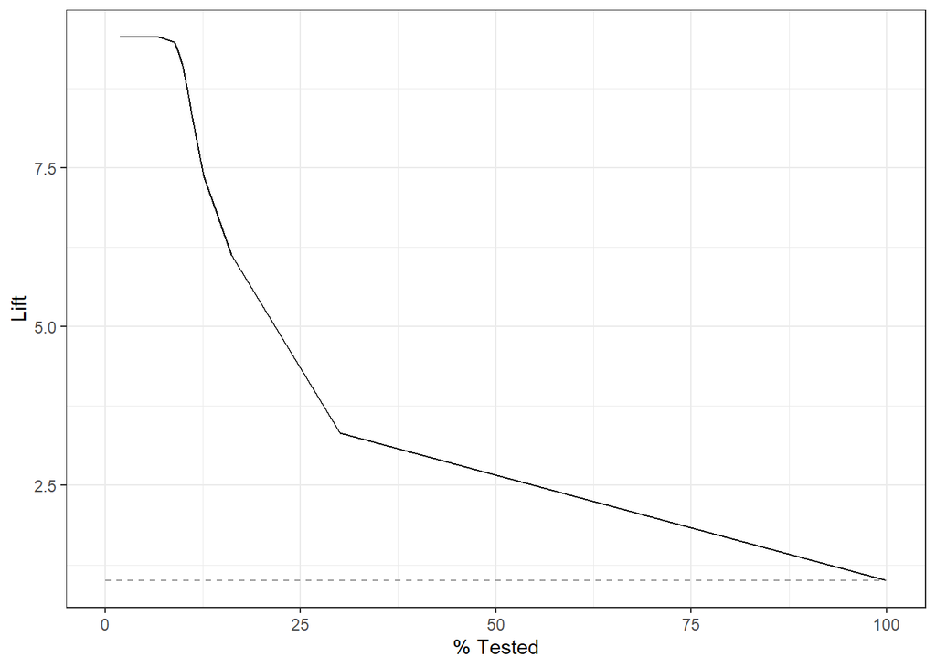

```r
tree_test_pred %>%
  lift_curve(truth = Personal_Loan,
             estimate = .pred_Yes) %>%
  autoplot()
```

### 중요변수 확인

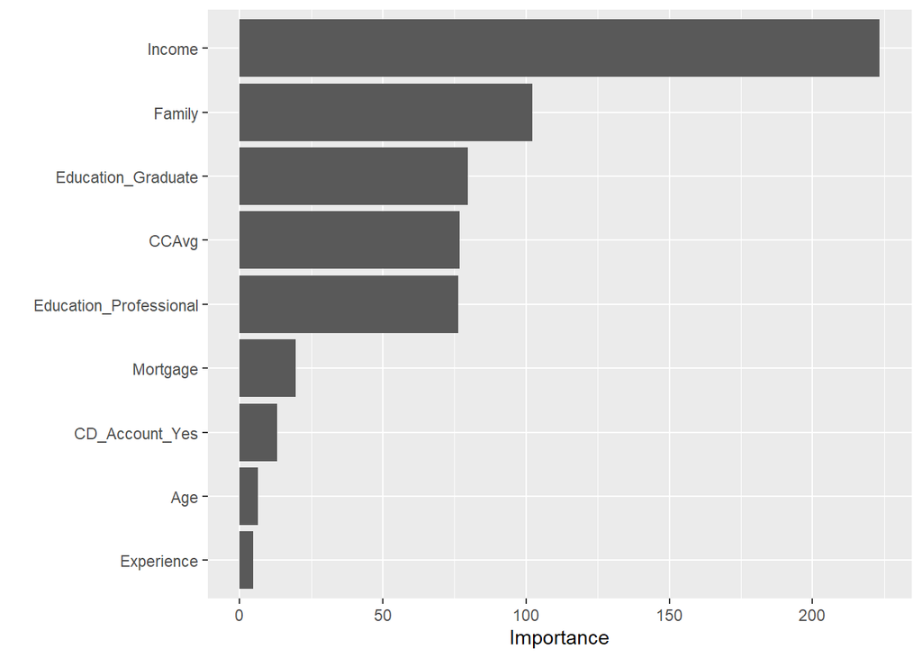

```r
tree_test_fit %>%
  pluck(".workflow", 1) %>%
  extract_fit_parsnip() %>% # `pull_workflow_fit()` was deprecated in workflows 0.2.3.
  vip(num_features = 20)
```

## train, test 검정결과 비교 ### 정오분류표(confusion matrix) 비교

```r
tree_train_conf
```

```
##           Truth
## Prediction  Yes   No
##        Yes  279   10
##        No    44 3167
```

```r
tree_test_conf
```

```
##           Truth
## Prediction  Yes   No
##        Yes  142    7
##        No    15 1336
```

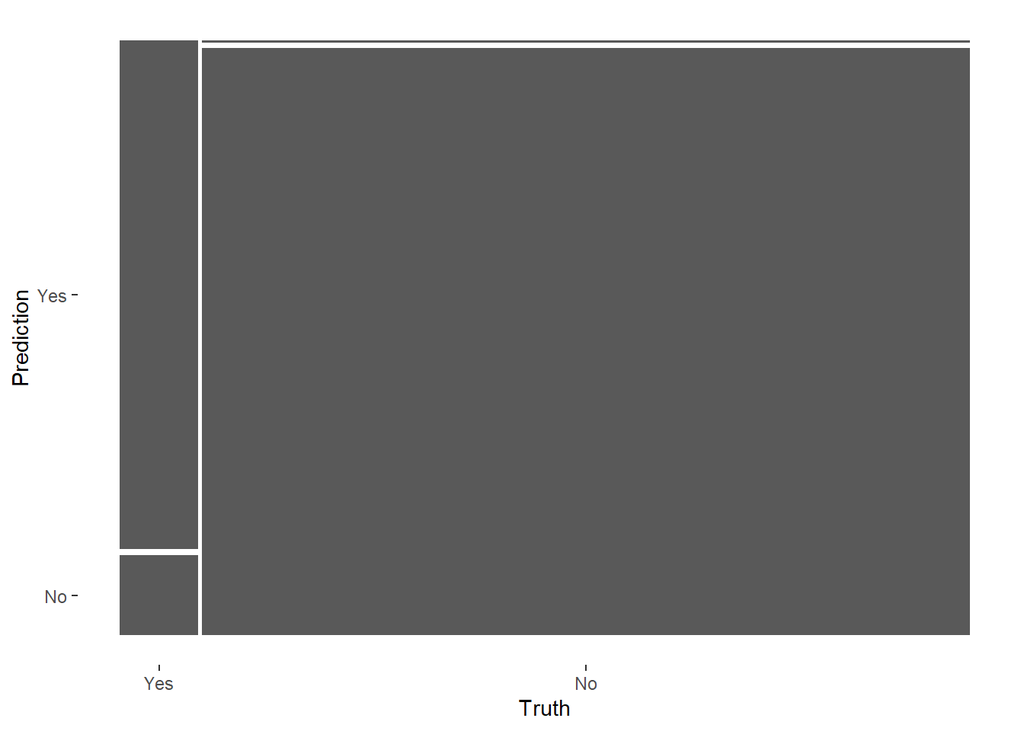

```r
autoplot(tree_train_conf, type = "mosaic") # mosaic
```

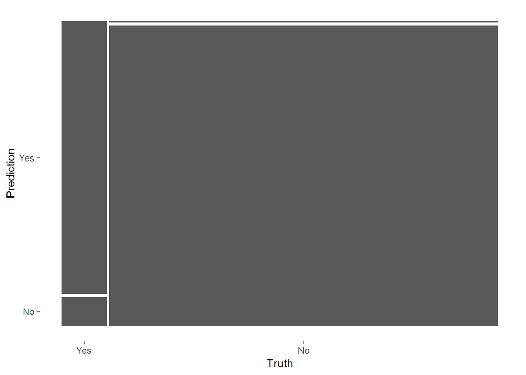

```r
autoplot(tree_test_conf, type = "mosaic")
```

### 검정결과 비교

```r
summary(tree_train_conf)
```

```
## # A tibble: 13 x 3
##    .metric              .estimator .estimate
##    <chr>                <chr>          <dbl>
##  1 accuracy             binary        0.985
##  2 kap                  binary        0.903
##  3 sens                 binary        0.864
##  4 spec                 binary        0.997
##  5 ppv                  binary        0.965
##  6 npv                  binary        0.986
##  7 mcc                  binary        0.905
##  8 j_index              binary        0.861
##  9 bal_accuracy         binary        0.930
## 10 detection_prevalence binary        0.0826
## 11 precision            binary        0.965
## 12 recall               binary        0.864
## 13 f_meas               binary        0.912
```

```r
summary(tree_test_conf)
```

```
## # A tibble: 13 x 3
##    .metric              .estimator .estimate
##    <chr>                <chr>          <dbl>
##  1 accuracy             binary        0.985
##  2 kap                  binary        0.920
##  3 sens                 binary        0.904
##  4 spec                 binary        0.995
##  5 ppv                  binary        0.953
##  6 npv                  binary        0.989
##  7 mcc                  binary        0.920
##  8 j_index              binary        0.899
##  9 bal_accuracy         binary        0.950
## 10 detection_prevalence binary        0.0993
## 11 precision            binary        0.953
## 12 recall               binary        0.904
## 13 f_meas               binary        0.928
```

### 1.9.7 ROC 커브 비교

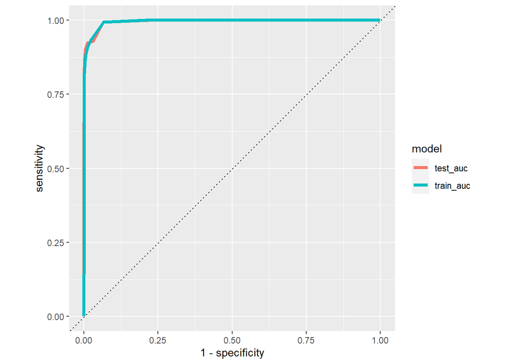

```r
bind_rows(train_auc, test_auc) %>%
  ggplot(aes(x = 1 - specificity,
             y = sensitivity,
             color = model)) +
  geom_path(lwd = 1.5) +
  geom_abline(lty = 3) +
  coord_equal()
```

## decision tree 만들기

```r
rpart_fit <-
  tree_train_fit %>%
  extract_fit_parsnip() # pull_workflow_fit()` was deprecated in workflows 0.2.3.
```

### 1.9.8 모형 1

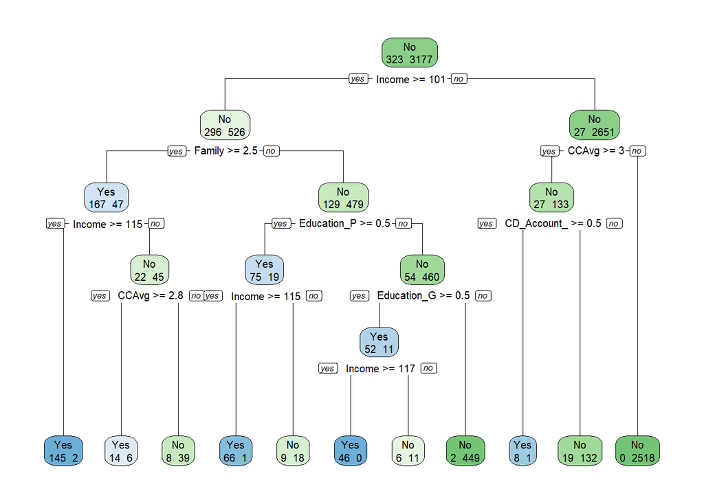

```r
rpart.plot(x = rpart_fit$fit,
           yesno = 2,
           type = 2,
           extra = 1,
           split.font = 1,
           varlen = -10,
           roundint=FALSE)
```

### 1.9.9 모형 2

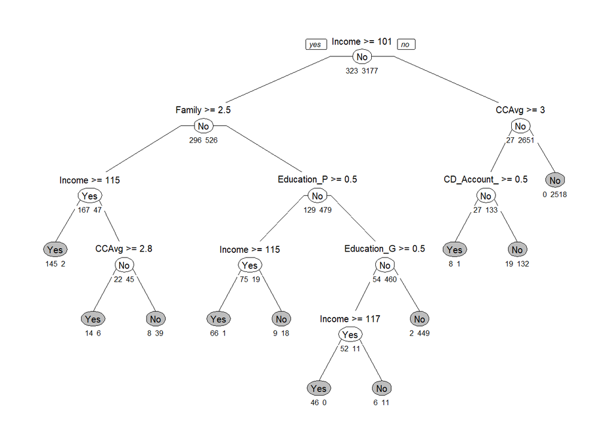

```r
prp(x = rpart_fit$fit,
    type = 1,
    extra = 1,
    under = TRUE,
    split.font = 1,
    varlen = -10,
    box.col=ifelse(rpart_fit$fit$frame$var == "<leaf>", 'gray', 'white'),
    roundint=FALSE)
```

help(prp) type = 나무그래프 표현 종류 extra= 추가 정보 표시, 1=노드의 관측수 표시 under= box 아래 관측값 표시, default=False split.font = 글자 font, default=2(bold) varlen = 변수이름 길이, default=-8, 0=full name box.col=box 색깔